# Data Preparation

Zhongwang (Eric) Huang

April 17, 2019

# Package Installation & Loading

```r
library(aod)
library(dplyr)
library(ggplot2)
library(sqldf)
library(RSQLite)
library(gsubfn)
library(proto)
library(forcats)
library(gmodels)
library(survival)
library(discSurv) #main package to perform discrete time-hazard analysis
library(car) #used to conduct ANOVA test
library(BCA) #used to generate variables summary
library(effects) #used to produce effect plot
library(fastDummies) #create dummy variables for categorical variables

#Set up working directory and paste the directory in the following command line source("/")
#All data files and R scripts should be saved under the same directory
```

# Dataset Merging

```r
#Comments on the data extraction of the CFE datafiles: ensure the order and naming convention of all variables are consistant

#Import candidate information from the CFE final datafiles. Lastest dataset can be added using the same command
CFE2016 = read.csv("2016CFE.csv")
CFE2017 = read.csv("2017CFE.csv")
CFE2018 = read.csv("2018CFE.csv")

#Further remove any null columns
CFE2017$X = NULL
CFE2017$X.1 = NULL
CFE2017$X.2 = NULL
CFE2017$X.3 = NULL
CFE2017$X.4 = NULL

#Input the merged data set from the previous BADM student group (Ben and Aria)
Data1518 = read.csv("2015-2018Data.csv")

##Union join all datasets. When adding additional files, copy and paste "CFEfinal <- sqldf("SELECT * FROM Data_final UNION SELECT * FROM FILENAME")" and replace "FILENAME" with new file name. This is the last step in adding new datasets.
CFEFinal <-  sqldf("SELECT * FROM CFE2016 UNION SELECT * FROM CFE2017")
CFEFinal <-  sqldf("SELECT * FROM CFEFinal UNION SELECT * FROM CFE2018")

#Left join the enrollment activities with candidate characteristics
CombDat1518 = sqldf("SELECT * FROM Data1518 LEFT JOIN CFEFinal ON Data1518.ID == CFEFinal.ID")

#Convert "NextRegStat" to binary variables
CombDat1518$NextRegStatBin = ifelse(CombDat1518$NextRegStatus == "REG", 1, 0)

#Save the data frame as .csv file
write.csv(CombDat1518, file = "CombDat1518.csv")
```

NOTE: Once the csv file is written, import to Tableau Prep to correct measurement errors and any required variable renaming. Cleaning steps performed in the Tableau Prep are documented in the workflow file. Please refer to the attachment for details.

# Data Restructure

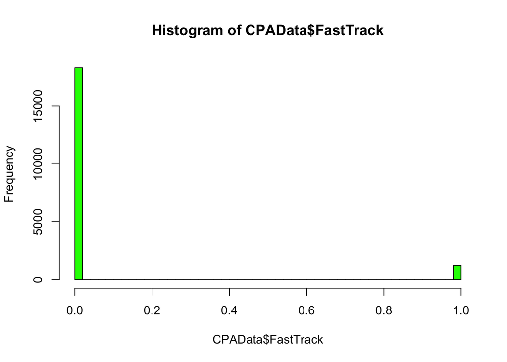

```r
#Input the merged and cleaned dataset from Tableau Prep
CPAData <- read.csv("CPADataCleaned_ver3.csv")

#FastTracker Summary for context
hist(CPAData$FastTrack, breaks = 60, col = "green")
```

```r
Fasttracker <- subset.data.frame(CPAData, FastTrack == 1,
                             select = c("ID", "DateCode", "ResultCopy", "ExamClass", "NextCourse", "NextSemEnroll","NextRegStatus_Binary", "SemestersBetween") ) #1223 rows

Fasttracker <- Fasttracker[!duplicated(Fasttracker$ID), ] #454 unique fasttracker candidates
```

# Data Entities Building

```r
#Build Core 1 data entity
#No Fasttrack students
C1_Data <- subset.data.frame(CPAData, ExamClass == 'C1' & FastTrack == 0,
                             select = c("ID", "DateCode", "ResultCopy", "ExamClass", "NextCourse", "NextSemEnroll","NextRegStatus_Binary", "SemestersBetween") )
#Rename "DateCode" to "C1_DateCode"
names(C1_Data)[names(C1_Data) == 'DateCode'] <- 'C1_DateCode'
names(C1_Data)[names(C1_Data) == 'NextCourse'] <- 'Post_C1_Course'
#Ensure the uniqueness by removing identical rows
C1_Data <- unique.data.frame(C1_Data) #3229 rows in general (not unique ID); 3062 unique candidates; 200 rows for retakers

#Building Core 2 data entity
C2_Data <- subset.data.frame(CPAData, ExamClass == 'C2' & FastTrack == 0,
                             select = c("ID", "DateCode", "ResultCopy", "ExamClass", "NextCourse", "NextSemEnroll","NextRegStatus_Binary", "SemestersBetween") )
#Rename the DataCode variable
names(C2_Data)[names(C2_Data) == 'DateCode'] <- 'C2_DateCode'
names(C2_Data)[names(C2_Data) == 'NextCourse'] <- 'Post_C2_Course'

#Ensure the uniqueness
C2_Data <- unique.data.frame(C2_Data) #4348 unique C2 takers

#Build entities for electives
TX_Data <- subset.data.frame(CPAData, ExamClass == 'TX' & FastTrack == 0,
                             select = c("ID", "DateCode", "ResultCopy", "ExamClass", "NextCourse", "NextSemEnroll","NextRegStatus_Binary", "SemestersBetween") )
FN_Data <- subset.data.frame(CPAData, ExamClass == 'FN' & FastTrack == 0,
                             select = c("ID", "DateCode", "ResultCopy", "ExamClass", "NextCourse", "NextSemEnroll","NextRegStatus_Binary", "SemestersBetween") )
AS_Data <- subset.data.frame(CPAData, ExamClass == 'AS' & FastTrack == 0,
                             select = c("ID", "DateCode", "ResultCopy", "ExamClass", "NextCourse", "NextSemEnroll","NextRegStatus_Binary", "SemestersBetween") )
PF_Data <- subset.data.frame(CPAData, ExamClass == 'PF' & FastTrack == 0,
                             select = c("ID", "DateCode", "ResultCopy", "ExamClass", "NextCourse", "NextSemEnroll","NextRegStatus_Binary", "SemestersBetween") )
#Rename variables to be more intuitive
names(TX_Data)[names(TX_Data) == 'DateCode'] <- 'TX_DateCode'
names(FN_Data)[names(FN_Data) == 'DateCode'] <- 'FN_DateCode'
names(AS_Data)[names(AS_Data) == 'DateCode'] <- 'AS_DateCode'
names(PF_Data)[names(PF_Data) == 'DateCode'] <- 'PF_DateCode'

names(TX_Data)[names(TX_Data) == 'NextCourse'] <- 'Post_TX_Course'
names(FN_Data)[names(FN_Data) == 'NextCourse'] <- 'Post_FN_Course'
names(AS_Data)[names(AS_Data) == 'NextCourse'] <- 'Post_AS_Course'
names(PF_Data)[names(PF_Data) == 'NextCourse'] <- 'Post_PF_Course'

#Build Candidate Characteristics Entity
Candidate_Data <- subset.data.frame(CPAData,
                                    select = c("ID", "ExamLocation","BusinessProvince", "PrereqGPA", "Employer_Cat", "LegacyPath", "Level", "FieldofStudy",
                                              "Major", "PrereqGPA", "ExperienceRoute", "Role", "Gender", "Age", "FastTrack" ))
#Ensure uniqueness of each candidate
Candidate_Data <- unique.data.frame(Candidate_Data) #remove identical rows
Candidate_Data <- Candidate_Data[!duplicated(Candidate_Data$ID), ] #5408 unique candidates in total
#Candidate_Data <- na.omit(Candidate_Data) #drop 22% of the candidates due to data incompleteness; this leaves 4139 candidates

#Create the candidate journey of the PEP
CPAJourney <- sqldf("SELECT C1_Data.ID, C1_DateCode, C2_DateCode, TX_DateCode, FN_DateCode, AS_DateCode, PF_DateCode,
                    ExamLocation, BusinessProvince, PrereqGPA, Employer_Cat, LegacyPath, Level, FieldofStudy, Major, PrereqGPA, ExperienceRoute, Role, Gender, Age, FastTrack
                    FROM C1_Data
                    LEFT JOIN C2_Data ON C1_Data.ID == C2_Data.ID
                    LEFT JOIN TX_Data ON C1_Data.ID == TX_Data.ID
                    LEFT JOIN FN_Data ON C1_Data.ID == FN_Data.ID
                    LEFT JOIN AS_Data ON C1_Data.ID == AS_Data.ID
                    LEFT JOIN PF_Data ON C1_Data.ID == PF_Data.ID
                    LEFT JOIN Candidate_Data ON C1_Data.ID == Candidate_Data.ID") #5419 to 4566
```

# Data Dictionary

ExamLocation: The city in which the candidate wrote their PEP exam.

BusinessProvince: The province of the candidate’s employer.

PrereqGPA: The GPA obtained by the candidate for their pre-requisite course.

Employer_Cat: The type of employer the candidate with which the candidate is employed. Large firms will be named, while smaller firms will simply be categorized as “small firms”.

LegacyPath: The previous path that the candidate was coming into the program from, if applicable (e.g. CGA, CMA, CA, etc)

Level: The level of post-secondary education obtained by the candidate (e.g. Bachelor, Master, etc)

FieldofStudy:The faculty that the candidate was enrolled in during their undergraduate degree (e.g. Business Administration)

Major: The specific concentration area within the candidate’s field of study, or faculty, during their undergraduate degree (e.g. Accounting, within the Business Admin faculty)

ExperienceRoute: Denotes whether the candidate is in the Pre-approved Program, Experience Verification route, or is unemployed.

Role: The job title of the candidate at their current firm. Roles are categorized into accountants, auditors, senior accountants/analysts, various management role. Any role that does not fit into any category is labeled as “other”.

Gender: The gender of the candidate.

Age: The age of the candidate.

Semester_DataLong: The current semester season for the time interval (e.g. Spring term; related to DateCode below).

DateCode: Identifies the year and semester of the entry using a concatenation.

- The first two digits are the current year within the century; i.e. 2017= 17
- The digits after the year are the semesters–denoted in increments of 2.5, as seen below: i.e. Fall2017= 175 Note: Can also refer to the previous BADM student group’s technical documentation for more context on DateCode, if needed.